# MoneyBall Project

Aaron Johnson

March 28, 2019

## Introduction

In this project I will attempt to explore and recreate the problem faced by the Oakland athletics baseball team in 2002.

### Background

*Source: Wikipedia*

The Oakland Athletics’ 2002 season was the team’s 35th in Oakland, California.

It was the 102nd season in franchise history. The Athletics finished first in the American League West with a record of 103-59.

The Athletics’ 2002 campaign ranks among the most famous in franchise history. Following the 2001 season, Oakland saw the departure of three key players. Billy Beane, the team’s general manager, responded with a series of under-the-radar free agent signings. The new-look Athletics, despite a comparative lack of star power, surprised the baseball world by besting the 2001 team’s regular season record. The team is most famous, however, for winning 20 consecutive games between August 13 and September 4, 2002.[1] The Athletics’ season was the subject of Michael Lewis’s 2003 book Moneyball: The Art of Winning an Unfair Game (Lewis was given the opportunity to follow the team around throughout the season). A film adaptation of the book, also titled Moneyball, was released in 2011.

### Objective

The three baseball statistics used in Moneyball to find replacement players are:

- [Batting Average](https://en.wikipedia.org/wiki/Batting_average)
- [On Base Percentage](https://en.wikipedia.org/wiki/On-base_percentage)
- [Slugging Percentage](https://en.wikipedia.org/wiki/Slugging_percentage)

With these formulas and the limited salary we have to work with, our guidelines for the replacement players are as follows:

- The total combined salary of the three players can not exceed 15 million dollars.
- Their combined number of At Bats (AB) needs to be equal to or greater than the lost players.
- Their mean OBP has to equal to or greater than the mean OBP of the lost players

Let’s get started.

### Data

The data we’ll be using comes from [Sean Lahman’s](http://www.seanlahman.com/baseball-archive/statistics/) baseball database website. Let’s go ahead and read in the data and check out the structure.

```r
batting <- read.csv('Batting.csv')
head(batting)
```

```
##    playerID yearID stint teamID lgID  G G_batting AB R H X2B X3B HR RBI SB
## 1 aardsda01   2004     1    SFN   NL 11        11  0 0 0   0   0  0   0  0
## 2 aardsda01   2006     1    CHN   NL 45        43  2 0 0   0   0  0   0  0
## 3 aardsda01   2007     1    CHA   AL 25         2  0 0 0   0   0  0   0  0
## 4 aardsda01   2008     1    BOS   AL 47         5  1 0 0   0   0  0   0  0
## 5 aardsda01   2009     1    SEA   AL 73         3  0 0 0   0   0  0   0  0
## 6 aardsda01   2010     1    SEA   AL 53         4  0 0 0   0   0  0   0  0
##   CS BB SO IBB HBP SH SF GIDP G_old
## 1  0  0  0   0   0  0  0    0    11
## 2  0  0  0   0   0  1  0    0    45
## 3  0  0  0   0   0  0  0    0     2
## 4  0  0  1   0   0  0  0    0     5
## 5  0  0  0   0   0  0  0    0    NA
## 6  0  0  0   0   0  0  0    0    NA
```

```r
str(batting)
```

```
## 'data.frame':    97889 obs. of  24 variables:
##  $ playerID : Factor w/ 18107 levels "aardsda01","aaronha01",..: 1 1 1 1 1 1 1 2 2 2 ...
##  $ yearID   : int  2004 2006 2007 2008 2009 2010 2012 1954 1955 1956 ...
##  $ stint    : int  1 1 1 1 1 1 1 1 1 1 ...
##  $ teamID   : Factor w/ 149 levels "ALT","ANA","ARI",..: 117 35 33 16 116 116 93 80 80 80 ...
##  $ lgID     : Factor w/ 6 levels "AA","AL","FL",..: 4 4 2 2 2 2 2 4 4 4 ...
##  $ G        : int  11 45 25 47 73 53 1 122 153 153 ...
##  $ G_batting: int  11 43 2 5 3 4 NA 122 153 153 ...
##  $ AB       : int  0 2 0 1 0 0 NA 468 602 609 ...
##  $ R        : int  0 0 0 0 0 0 NA 58 105 106 ...
##  $ H        : int  0 0 0 0 0 0 NA 131 189 200 ...
##  $ X2B      : int  0 0 0 0 0 0 NA 27 37 34 ...
##  $ X3B      : int  0 0 0 0 0 0 NA 6 9 14 ...
##  $ HR       : int  0 0 0 0 0 0 NA 13 27 26 ...
##  $ RBI      : int  0 0 0 0 0 0 NA 69 106 92 ...
##  $ SB       : int  0 0 0 0 0 0 NA 2 3 2 ...
##  $ CS       : int  0 0 0 0 0 0 NA 2 1 4 ...
##  $ BB       : int  0 0 0 0 0 0 NA 28 49 37 ...
##  $ SO       : int  0 0 0 1 0 0 NA 39 61 54 ...
##  $ IBB      : int  0 0 0 0 0 0 NA NA 5 6 ...
##  $ HBP      : int  0 0 0 0 0 0 NA 3 3 2 ...
##  $ SH       : int  0 1 0 0 0 0 NA 6 7 5 ...
##  $ SF       : int  0 0 0 0 0 0 NA 4 4 7 ...
##  $ GIDP     : int  0 0 0 0 0 0 NA 13 20 21 ...
##  $ G_old    : int  11 45 2 5 NA NA NA 122 153 153 ...
```

Looking at this data we can see that three statistics we need are not in this data, but can be created using the stats we do have.

### Feature Engineering

As mentioned above, we’ll need to create new statistics from out existing data. Again these statistics are:

- [Batting Average](https://en.wikipedia.org/wiki/Batting_average)
- [On Base Percentage](https://en.wikipedia.org/wiki/On-base_percentage)
- [Slugging Percentage](https://en.wikipedia.org/wiki/Slugging_percentage)

#### Batting Average

```r
batting$BA <- batting$H / batting$AB
```

```r
tail(batting$BA, 5)
```

```
## [1] 0.1230769 0.2746479 0.1470588 0.2745098 0.2138728
```

#### On Base Percentage

```r
batting$OBP <- (batting$H + batting$BB + batting$HBP) / (batting$AB + batting$BB + batting$HBP + batting$SF)
```

#### Slugging Percentage

This formula requires the 1B (Singles) statistic. This is not included in our dataset, but we can create it:

```r
batting$X1B <- batting$H - batting$X2B - batting$X3B - batting$HR
batting$SLG <- (batting$X1B + (2 * batting$X2B) + (3 * batting$X3B) + (4 * batting$HR)) / batting$AB
```

Let’s check the structure of the dataframe again:

```r
str(batting)
```

```
## 'data.frame':    97889 obs. of  28 variables:
##  $ playerID : Factor w/ 18107 levels "aardsda01","aaronha01",..: 1 1 1 1 1 1 1 2 2 2 ...
##  $ yearID   : int  2004 2006 2007 2008 2009 2010 2012 1954 1955 1956 ...
##  $ stint    : int  1 1 1 1 1 1 1 1 1 1 ...
##  $ teamID   : Factor w/ 149 levels "ALT","ANA","ARI",..: 117 35 33 16 116 116 93 80 80 80 ...
##  $ lgID     : Factor w/ 6 levels "AA","AL","FL",..: 4 4 2 2 2 2 2 4 4 4 ...
##  $ G        : int  11 45 25 47 73 53 1 122 153 153 ...
##  $ G_batting: int  11 43 2 5 3 4 NA 122 153 153 ...
##  $ AB       : int  0 2 0 1 0 0 NA 468 602 609 ...
##  $ R        : int  0 0 0 0 0 0 NA 58 105 106 ...
##  $ H        : int  0 0 0 0 0 0 NA 131 189 200 ...
##  $ X2B      : int  0 0 0 0 0 0 NA 27 37 34 ...
##  $ X3B      : int  0 0 0 0 0 0 NA 6 9 14 ...
##  $ HR       : int  0 0 0 0 0 0 NA 13 27 26 ...
##  $ RBI      : int  0 0 0 0 0 0 NA 69 106 92 ...
##  $ SB       : int  0 0 0 0 0 0 NA 2 3 2 ...
##  $ CS       : int  0 0 0 0 0 0 NA 2 1 4 ...
##  $ BB       : int  0 0 0 0 0 0 NA 28 49 37 ...
##  $ SO       : int  0 0 0 1 0 0 NA 39 61 54 ...
##  $ IBB      : int  0 0 0 0 0 0 NA NA 5 6 ...
##  $ HBP      : int  0 0 0 0 0 0 NA 3 3 2 ...
##  $ SH       : int  0 1 0 0 0 0 NA 6 7 5 ...
##  $ SF       : int  0 0 0 0 0 0 NA 4 4 7 ...
##  $ GIDP     : int  0 0 0 0 0 0 NA 13 20 21 ...
##  $ G_old    : int  11 45 2 5 NA NA NA 122 153 153 ...
##  $ BA       : num  NaN 0 NaN 0 NaN ...
##  $ OBP      : num  NaN 0 NaN 0 NaN ...
##  $ X1B      : int  0 0 0 0 0 0 NA 85 116 126 ...
##  $ SLG      : num  NaN 0 NaN 0 NaN ...
```

We can see that we now have all the required statistics we’ll need in our data set.

### Merging Salary Data with Batting Data

In order to find our replacements, we’ll need to merge our batting data with salary data for each player.

#### Loading the salary data

```r
sal <- read.csv('Salaries.csv')
```

```r
summary(sal)
```

```
##      yearID         teamID      lgID            playerID
##  Min.   :1985   CLE    :  867   AL:11744   moyerja01:   25
##  1st Qu.:1993   LAN    :  861   NL:12212   vizquom01:   24
##  Median :1999   PHI    :  861              glavito02:   23
##  Mean   :1999   SLN    :  858              bondsba01:   22
##  3rd Qu.:2006   BAL    :  855              griffke02:   22
##  Max.   :2013   NYA    :  855              thomeji01:   22
##                 (Other):18799              (Other)  :23818
##      salary
##  Min.   :       0
##  1st Qu.:  250000
##  Median :  507950
##  Mean   : 1864357
##  3rd Qu.: 2100000
##  Max.   :33000000
##
```

```r
summary(batting)
```

```
##       playerID         yearID         stint           teamID
##  mcguide01:   31   Min.   :1871   Min.   :1.000   CHN    : 4720
##  henderi01:   29   1st Qu.:1931   1st Qu.:1.000   PHI    : 4621
##  newsobo01:   29   Median :1970   Median :1.000   PIT    : 4575
##  johnto01 :   28   Mean   :1962   Mean   :1.077   SLN    : 4535
##  kaatji01 :   28   3rd Qu.:1995   3rd Qu.:1.000   CIN    : 4393
##  ansonca01:   27   Max.   :2013   Max.   :5.000   CLE    : 4318
##  (Other)  :97717                                  (Other):70727
##    lgID             G            G_batting            AB
##  AA  : 1890   Min.   :  1.00   Min.   :  0.00   Min.   :  0.0
##  AL  :44369   1st Qu.: 13.00   1st Qu.:  7.00   1st Qu.:  9.0
##  FL  :  470   Median : 35.00   Median : 32.00   Median : 61.0
##  NL  :49944   Mean   : 51.65   Mean   : 49.13   Mean   :154.1
##  PL  :  147   3rd Qu.: 81.00   3rd Qu.: 81.00   3rd Qu.:260.0
##  UA  :  332   Max.   :165.00   Max.   :165.00   Max.   :716.0
##  NA's:  737                    NA's   :1406     NA's   :6413
##        R                H               X2B            X3B
##  Min.   :  0.00   Min.   :  0.00   Min.   : 0.0   Min.   : 0.000
##  1st Qu.:  0.00   1st Qu.:  1.00   1st Qu.: 0.0   1st Qu.: 0.000
##  Median :  5.00   Median : 12.00   Median : 2.0   Median : 0.000
##  Mean   : 20.47   Mean   : 40.37   Mean   : 6.8   Mean   : 1.424
##  3rd Qu.: 31.00   3rd Qu.: 66.00   3rd Qu.:10.0   3rd Qu.: 2.000
##  Max.   :192.00   Max.   :262.00   Max.   :67.0   Max.   :36.000
##  NA's   :6413     NA's   :6413     NA's   :6413   NA's   :6413
##        HR              RBI               SB                CS
##  Min.   : 0.000   Min.   :  0.00   Min.   :  0.000   Min.   : 0.000
##  1st Qu.: 0.000   1st Qu.:  0.00   1st Qu.:  0.000   1st Qu.: 0.000
##  Median : 0.000   Median :  5.00   Median :  0.000   Median : 0.000
##  Mean   : 3.002   Mean   : 18.47   Mean   :  3.265   Mean   : 1.385
##  3rd Qu.: 3.000   3rd Qu.: 28.00   3rd Qu.:  2.000   3rd Qu.: 1.000
##  Max.   :73.000   Max.   :191.00   Max.   :138.000   Max.   :42.000
##  NA's   :6413     NA's   :6837     NA's   :7713      NA's   :29867
##        BB               SO              IBB              HBP
##  Min.   :  0.00   Min.   :  0.00   Min.   :  0.00   Min.   : 0.000
##  1st Qu.:  0.00   1st Qu.:  2.00   1st Qu.:  0.00   1st Qu.: 0.000
##  Median :  4.00   Median : 11.00   Median :  0.00   Median : 0.000
##  Mean   : 14.21   Mean   : 21.95   Mean   :  1.28   Mean   : 1.136
##  3rd Qu.: 21.00   3rd Qu.: 31.00   3rd Qu.:  1.00   3rd Qu.: 1.000
##  Max.   :232.00   Max.   :223.00   Max.   :120.00   Max.   :51.000
##  NA's   :6413     NA's   :14251    NA's   :42977    NA's   :9233
##        SH               SF             GIDP           G_old
##  Min.   : 0.000   Min.   : 0.0    Min.   : 0.00   Min.   :  0.00
##  1st Qu.: 0.000   1st Qu.: 0.0    1st Qu.: 0.00   1st Qu.: 11.00
##  Median : 1.000   Median : 0.0    Median : 1.00   Median : 34.00
##  Mean   : 2.564   Mean   : 1.2    Mean   : 3.33   Mean   : 50.99
##  3rd Qu.: 3.000   3rd Qu.: 2.0    3rd Qu.: 5.00   3rd Qu.: 82.00
##  Max.   :67.000   Max.   :19.0    Max.   :36.00   Max.   :165.00
##  NA's   :12751    NA's   :42446   NA's   :32521   NA's   :5189
##        BA             OBP             X1B              SLG
##  Min.   :0.000   Min.   :0.00    Min.   :  0.00   Min.   :0.000
##  1st Qu.:0.148   1st Qu.:0.19    1st Qu.:  1.00   1st Qu.:0.179
##  Median :0.231   Median :0.29    Median :  9.00   Median :0.309
##  Mean   :0.209   Mean   :0.26    Mean   : 29.14   Mean   :0.291
##  3rd Qu.:0.275   3rd Qu.:0.34    3rd Qu.: 48.00   3rd Qu.:0.397
##  Max.   :1.000   Max.   :1.00    Max.   :225.00   Max.   :4.000
##  NA's   :13520   NA's   :49115   NA's   :6413     NA's   :13520
```

```r
batting <- subset(batting, yearID > 1984 )
```

```r
summary(batting)
```

```
##       playerID         yearID         stint          teamID
##  moyerja01:   27   Min.   :1985   Min.   :1.00   SDN    : 1313
##  mulhote01:   26   1st Qu.:1993   1st Qu.:1.00   CLE    : 1306
##  weathda01:   26   Median :2000   Median :1.00   PIT    : 1299
##  maddugr01:   25   Mean   :2000   Mean   :1.08   NYN    : 1297
##  sierrru01:   25   3rd Qu.:2007   3rd Qu.:1.00   BOS    : 1279
##  thomeji01:   25   Max.   :2013   Max.   :4.00   CIN    : 1279
##  (Other)  :35498                                 (Other):27879
##  lgID             G           G_batting            AB
##  AA:    0   Min.   :  1.0   Min.   :  0.00   Min.   :  0.0
##  AL:17226   1st Qu.: 14.0   1st Qu.:  4.00   1st Qu.:  3.0
##  FL:    0   Median : 34.0   Median : 27.00   Median : 47.0
##  NL:18426   Mean   : 51.7   Mean   : 46.28   Mean   :144.7
##  PL:    0   3rd Qu.: 77.0   3rd Qu.: 77.00   3rd Qu.:241.0
##  UA:    0   Max.   :163.0   Max.   :163.00   Max.   :716.0
##                             NA's   :1406     NA's   :4377
##        R                H               X2B              X3B
##  Min.   :  0.00   Min.   :  0.00   Min.   : 0.000   Min.   : 0.000
##  1st Qu.:  0.00   1st Qu.:  0.00   1st Qu.: 0.000   1st Qu.: 0.000
##  Median :  4.00   Median :  8.00   Median : 1.000   Median : 0.000
##  Mean   : 19.44   Mean   : 37.95   Mean   : 7.293   Mean   : 0.824
##  3rd Qu.: 30.00   3rd Qu.: 61.00   3rd Qu.:11.000   3rd Qu.: 1.000
##  Max.   :152.00   Max.   :262.00   Max.   :59.000   Max.   :23.000
##  NA's   :4377     NA's   :4377     NA's   :4377     NA's   :4377
##        HR              RBI               SB                CS
##  Min.   : 0.000   Min.   :  0.00   Min.   :  0.000   Min.   : 0.000
##  1st Qu.: 0.000   1st Qu.:  0.00   1st Qu.:  0.000   1st Qu.: 0.000
##  Median : 0.000   Median :  3.00   Median :  0.000   Median : 0.000
##  Mean   : 4.169   Mean   : 18.41   Mean   :  2.811   Mean   : 1.219
##  3rd Qu.: 5.000   3rd Qu.: 27.00   3rd Qu.:  2.000   3rd Qu.: 1.000
##  Max.   :73.000   Max.   :165.00   Max.   :110.000   Max.   :29.000
##  NA's   :4377     NA's   :4377     NA's   :4377      NA's   :4377
##        BB               SO              IBB               HBP
##  Min.   :  0.00   Min.   :  0.00   Min.   :  0.000   Min.   : 0.000
##  1st Qu.:  0.00   1st Qu.:  1.00   1st Qu.:  0.000   1st Qu.: 0.000
##  Median :  3.00   Median : 12.00   Median :  0.000   Median : 0.000
##  Mean   : 14.06   Mean   : 27.03   Mean   :  1.171   Mean   : 1.273
##  3rd Qu.: 21.00   3rd Qu.: 42.00   3rd Qu.:  1.000   3rd Qu.: 1.000
##  Max.   :232.00   Max.   :223.00   Max.   :120.000   Max.   :35.000
##  NA's   :4377     NA's   :4377     NA's   :4378      NA's   :4387
##        SH               SF              GIDP           G_old
##  Min.   : 0.000   Min.   : 0.000   Min.   : 0.00   Min.   :  0.0
##  1st Qu.: 0.000   1st Qu.: 0.000   1st Qu.: 0.00   1st Qu.: 11.0
##  Median : 0.000   Median : 0.000   Median : 1.00   Median : 32.0
##  Mean   : 1.465   Mean   : 1.212   Mean   : 3.25   Mean   : 49.7
##  3rd Qu.: 2.000   3rd Qu.: 2.000   3rd Qu.: 5.00   3rd Qu.: 77.0
##  Max.   :39.000   Max.   :17.000   Max.   :35.00   Max.   :163.0
##  NA's   :4377     NA's   :4378     NA's   :4377    NA's   :5189
##        BA             OBP             X1B              SLG
##  Min.   :0.000   Min.   :0.000   Min.   :  0.00   Min.   :0.000
##  1st Qu.:0.136   1st Qu.:0.188   1st Qu.:  0.00   1st Qu.:0.167
##  Median :0.233   Median :0.296   Median :  6.00   Median :0.333
##  Mean   :0.205   Mean   :0.262   Mean   : 25.66   Mean   :0.304
##  3rd Qu.:0.274   3rd Qu.:0.342   3rd Qu.: 42.00   3rd Qu.:0.423
##  Max.   :1.000   Max.   :1.000   Max.   :225.00   Max.   :4.000
##  NA's   :8905    NA's   :8821    NA's   :4377     NA's   :8905
```

Now we can merge the batting data with the salary data. We’ll need to merge on *both* players and years since we have players playing multiple years.

```r
combo <- merge(batting,sal, by = c('playerID', 'yearID'))
```

```r
summary(combo)
```

```
##       playerID         yearID         stint          teamID.x
##  moyerja01:   27   Min.   :1985   Min.   :1.000   LAN    :  940
##  thomeji01:   25   1st Qu.:1993   1st Qu.:1.000   PHI    :  937
##  weathda01:   25   Median :1999   Median :1.000   BOS    :  935
##  vizquom01:   24   Mean   :1999   Mean   :1.098   NYA    :  928
##  gaettga01:   23   3rd Qu.:2006   3rd Qu.:1.000   CLE    :  920
##  griffke02:   23   Max.   :2013   Max.   :4.000   SDN    :  914
##  (Other)  :25250                                  (Other):19823
##  lgID.x           G            G_batting            AB
##  AA:    0   Min.   :  1.00   Min.   :  0.00   Min.   :  0.0
##  AL:12292   1st Qu.: 26.00   1st Qu.:  8.00   1st Qu.:  5.0
##  FL:    0   Median : 50.00   Median : 42.00   Median : 85.0
##  NL:13105   Mean   : 64.06   Mean   : 57.58   Mean   :182.4
##  PL:    0   3rd Qu.:101.00   3rd Qu.:101.00   3rd Qu.:336.0
##  UA:    0   Max.   :163.00   Max.   :163.00   Max.   :716.0
##                              NA's   :906      NA's   :2661
##        R                H               X2B              X3B
##  Min.   :  0.00   Min.   :  0.00   Min.   : 0.000   Min.   : 0.000
##  1st Qu.:  0.00   1st Qu.:  1.00   1st Qu.: 0.000   1st Qu.: 0.000
##  Median :  9.00   Median : 19.00   Median : 3.000   Median : 0.000
##  Mean   : 24.71   Mean   : 48.18   Mean   : 9.276   Mean   : 1.033
##  3rd Qu.: 43.00   3rd Qu.: 87.25   3rd Qu.:16.000   3rd Qu.: 1.000
##  Max.   :152.00   Max.   :262.00   Max.   :59.000   Max.   :23.000
##  NA's   :2661     NA's   :2661     NA's   :2661     NA's   :2661
##        HR              RBI               SB                CS
##  Min.   : 0.000   Min.   :  0.00   Min.   :  0.000   Min.   : 0.00
##  1st Qu.: 0.000   1st Qu.:  0.00   1st Qu.:  0.000   1st Qu.: 0.00
##  Median : 1.000   Median :  8.00   Median :  0.000   Median : 0.00
##  Mean   : 5.369   Mean   : 23.56   Mean   :  3.568   Mean   : 1.54
##  3rd Qu.: 7.000   3rd Qu.: 39.00   3rd Qu.:  3.000   3rd Qu.: 2.00
##  Max.   :73.000   Max.   :165.00   Max.   :110.000   Max.   :29.00
##  NA's   :2661     NA's   :2661     NA's   :2661      NA's   :2661
##        BB               SO              IBB               HBP
##  Min.   :  0.00   Min.   :  0.00   Min.   :  0.000   Min.   : 0.000
##  1st Qu.:  0.00   1st Qu.:  2.00   1st Qu.:  0.000   1st Qu.: 0.000
##  Median :  6.00   Median : 20.00   Median :  0.000   Median : 0.000
##  Mean   : 17.98   Mean   : 33.52   Mean   :  1.533   Mean   : 1.614
##  3rd Qu.: 29.00   3rd Qu.: 55.00   3rd Qu.:  2.000   3rd Qu.: 2.000
##  Max.   :232.00   Max.   :223.00   Max.   :120.000   Max.   :35.000
##  NA's   :2661     NA's   :2661     NA's   :2662      NA's   :2670
```

[output cut: 9 more lines]

```
##  Min.   :0.000   Min.   :0.000   Min.   :  0.0   Min.   :0.000
##  1st Qu.:0.160   1st Qu.:0.208   1st Qu.:  0.0   1st Qu.:0.200
##  Median :0.242   Median :0.305   Median : 13.0   Median :0.351
##  Mean   :0.212   Mean   :0.270   Mean   : 32.5   Mean   :0.317
##  3rd Qu.:0.276   3rd Qu.:0.346   3rd Qu.: 59.0   3rd Qu.:0.432
##  Max.   :1.000   Max.   :1.000   Max.   :225.0   Max.   :4.000
##  NA's   :5618    NA's   :5562    NA's   :2661    NA's   :5618
##     teamID.y     lgID.y         salary
##  CLE    :  935   AL:12304   Min.   :       0
##  PIT    :  932   NL:13093   1st Qu.:  255000
##  PHI    :  931              Median :  550000
##  SDN    :  923              Mean   : 1879256
##  LAN    :  921              3rd Qu.: 2150000
##  CIN    :  912              Max.   :33000000
##  (Other):19843
```

### Analyzing the Lost Players

Let’s create a subset of the three free agents that left the team so that we can easily analize their stats.

```r
lost_players <- subset(combo, playerID %in% c('giambja01', 'damonjo01', 'saenzol01'))
```

Since these players were lost in 2001, let’s only look at the data from that year.

```r
lost_players <- lost_players %>% filter(yearID == 2001)
```

Let’s educe the lost_players data frame to the essential variables.

```r
lost_players <- lost_players %>% select(playerID, H, X2B, X3B, HR, OBP, SLG, BA, AB)
```

```r
lost_players
```

```
##    playerID   H X2B X3B HR       OBP       SLG        BA  AB
## 1 damonjo01 165  34   4  9 0.3235294 0.3633540 0.2562112 644
## 2 giambja01 178  47   2 38 0.4769001 0.6596154 0.3423077 520
## 3 saenzol01  67  21   1  9 0.2911765 0.3836066 0.2196721 305
```

### Replacement Players

Now, we’ll go through our dataset to find replacements for our lost players. Again our requirements are as follows:

- The total combined salary of the three players can not exceed 15 million dollars.
- Their combined number of At Bats (AB) needs to be equal to or greater than the lost players.
- Their mean OBP has to equal to or greater than the mean OBP of the lost players

First, let’s see what the combined **AB** is for our lost players.

```r
lost_combined_AB <- sum(lost_players$AB)
print(lost_combined_AB)
```

```
## [1] 1469
```

Next, we’ll see what their mean **OBP** is.

```r
lost_combined_mean<- mean(lost_players$OBP)
print(lost_combined_mean)
```

```
## [1] 0.3638687
```

Since this happened in the year 2001, we can subset our main dataset to just look at that year.

```r
combo <- combo %>% filter(yearID == 2001)
```

```r
str(combo)
```

```
## 'data.frame':    915 obs. of  31 variables:
##  $ playerID : Factor w/ 18107 levels "aardsda01","aaronha01",..: 14 16 19 34 86 108 167 168 170 179 ...
##  $ yearID   : int  2001 2001 2001 2001 2001 2001 2001 2001 2001 2001 ...
##  $ stint    : int  1 1 1 1 1 1 1 1 1 1 ...
##  $ teamID.x : Factor w/ 149 levels "ALT","ANA","ARI",..: 55 4 116 102 72 94 55 94 66 79 ...
##  $ lgID.x   : Factor w/ 6 levels "AA","AL","FL",..: 4 4 2 4 4 4 4 4 2 2 ...
##  $ G        : int  28 6 28 162 43 91 58 124 113 57 ...
##  $ G_batting: int  28 6 2 162 41 91 54 124 113 57 ...
##  $ AB       : int  42 9 4 588 39 296 0 457 387 175 ...
##  $ R        : int  5 0 0 118 2 28 0 64 44 20 ...
##  $ H        : int  11 2 1 170 2 82 0 111 106 46 ...
##  $ X2B      : int  3 0 0 48 1 14 0 22 16 13 ...
##  $ X3B      : int  0 0 0 4 0 2 0 0 4 2 ...
##  $ HR       : int  0 0 0 31 0 6 0 17 4 4 ...
##  $ RBI      : int  5 0 0 110 1 27 0 49 32 20 ...
```

[output cut: 17 more lines]

In order to get a sense of where our replacement players might come from, let’s plot our data by **salary** and **OBP**

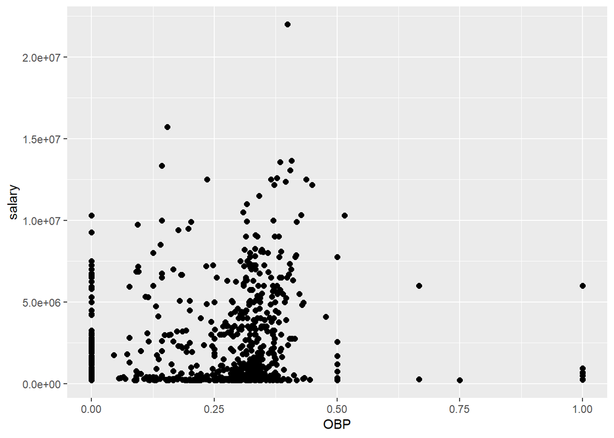

```r
ggplot(combo, aes(x=OBP, y=salary)) + geom_point(size=2)
```

We have quite a few records stacked at 0. This could just be represented by players who have not yet batted or did not make it to base. We also see that there are planty of records for **OBP** that are *both* well under a third of our salary cap, *and* are around our target mean *OBP* of 0.36. It makes sense then to subset our data to records where the **OBP** is greater than zero, and our **salary** is less than $8,000,000.

```r
combo <- subset(combo, salary < 8000000 & OBP > 0)
str(combo)
```

```
## 'data.frame':    602 obs. of  31 variables:
##  $ playerID : Factor w/ 18107 levels "aardsda01","aaronha01",..: 14 16 19 34 86 108 168 170 179 228 ...
##  $ yearID   : int  2001 2001 2001 2001 2001 2001 2001 2001 2001 2001 ...
##  $ stint    : int  1 1 1 1 1 1 1 1 1 1 ...
##  $ teamID.x : Factor w/ 149 levels "ALT","ANA","ARI",..: 55 4 116 102 72 94 94 66 79 45 ...
##  $ lgID.x   : Factor w/ 6 levels "AA","AL","FL",..: 4 4 2 4 4 4 4 2 2 2 ...
##  $ G        : int  28 6 28 162 43 91 124 113 57 157 ...
##  $ G_batting: int  28 6 2 162 41 91 124 113 57 157 ...
##  $ AB       : int  42 9 4 588 39 296 457 387 175 575 ...
##  $ R        : int  5 0 0 118 2 28 64 44 20 113 ...
##  $ H        : int  11 2 1 170 2 82 111 106 46 193 ...
##  $ X2B      : int  3 0 0 48 1 14 22 16 13 34 ...
##  $ X3B      : int  0 0 0 4 0 2 0 4 2 12 ...
##  $ HR       : int  0 0 0 31 0 6 17 4 4 20 ...
##  $ RBI      : int  5 0 0 110 1 27 49 32 20 100 ...
```

[output cut: 17 more lines]

Looking at the at-bat(AB) statistic, we probably want to target around 450, since the total **AB** for our **lost_players** was 1,469. 1,469 divided by 3 is about 489.6667, so we need to start our limit slightly below this. 450 seems like a good cutoff.

```r
combo <- subset(combo, AB >=450)
str(combo)
```

```
## 'data.frame':    122 obs. of  31 variables:
##  $ playerID : Factor w/ 18107 levels "aardsda01","aaronha01",..: 34 168 228 235 303 319 488 554 778 1020 ...
##  $ yearID   : int  2001 2001 2001 2001 2001 2001 2001 2001 2001 2001 ...
##  $ stint    : int  1 1 1 1 1 1 1 1 1 1 ...
##  $ teamID.x : Factor w/ 149 levels "ALT","ANA","ARI",..: 102 94 45 58 2 102 117 58 86 116 ...
##  $ lgID.x   : Factor w/ 6 levels "AA","AL","FL",..: 4 4 2 4 2 4 4 4 4 2 ...
##  $ G        : int  162 124 157 136 161 147 156 161 132 135 ...
##  $ G_batting: int  162 124 157 136 161 147 156 161 132 135 ...
##  $ AB       : int  588 457 575 513 672 522 636 600 472 470 ...
##  $ R        : int  118 64 113 79 83 69 114 126 42 62 ...
##  $ H        : int  170 111 193 170 194 153 206 173 118 122 ...
##  $ X2B      : int  48 22 34 31 39 30 37 43 33 28 ...
##  $ X3B      : int  4 0 12 1 2 2 5 4 2 0 ...
##  $ HR       : int  31 17 20 27 28 11 37 39 6 15 ...
##  $ RBI      : int  110 49 100 108 123 61 97 130 38 64 ...
```

[output cut: 17 more lines]

We’ve narrowed down our options quite a bit. Let’s use the dplyr library to quickly arrange what’s left of combo.

```r
options <- head(arrange(combo, desc(OBP)), 10)
```

```r
options %>% select(playerID, AB, salary, OBP)
```

```
##     playerID  AB  salary       OBP
## 1  giambja01 520 4103333 0.4769001
## 2  heltoto01 587 4950000 0.4316547
## 3  berkmla01 577  305000 0.4302326
## 4  gonzalu01 609 4833333 0.4285714
## 5  martied01 470 5500000 0.4234079
## 6  thomeji01 526 7875000 0.4161491
## 7  alomaro01 575 7750000 0.4146707
## 8  edmonji01 500 6333333 0.4102142
## 9  gilesbr02 576 7333333 0.4035608
## 10 pujolal01 590  200000 0.4029630
```

Looking at this output we know we can’t pick the first listed player as he is one of the players who left. But the next three on the list look like great replacements. Let’s look at just these players to confirm that they meet all of our requirements:

```r
replacements <- subset(combo, playerID %in% c('heltoto01', 'berkmla01', 'gonzalu01'))
```

#### The total combined salary of the three players can not exceed 15 million dollars.

```r
sum(replacements$salary) <= 15000000
```

```
## [1] TRUE
```

#### Their combined number of At Bats (AB) needs to be equal to or greater than the lost players.

```r
sum(replacements$AB) >= sum(lost_players$AB)
```

```
## [1] TRUE
```

#### Their mean OBP had to equal to or greater than the mean OBP of the lost players

```r
mean(replacements$OBP) >= mean(lost_players$OBP)
```

```
## [1] TRUE
```

### Conclusion

##### Assumptions

We made a big assumption that every player in our data set (other than the lost players) was a free agent, and thus available as replacements. In reality we’d be restricted in our choices even further because a portion of the players would already be signed to other teams. To take this project further we could get free agent data for the year 2001 so that we could see who would have actually been available as a replacement.